# Case Study: How Does a Bike-Share Navigate Speedy Success?

Kimathi Nyota

2023-04-18

The purpose of this document is to detail my overall process for exploring a given Case Study, going from accessing the data to finding insights that answer the specified business task.

# Business Task

- Cyclistic is a fictional bike share program with a network of 692 bike stations and 5,824 Geo-tracked bicycles that can be returned (and fetched) to any station at anytime.
- They offer several pricing plans: single-ride and full-day passes and annual memberships.
- Cylistic members are categorised as follows:
  - Casual riders, who purchase single-ride or full-day passes
  - Member riders, who purchase annual memberships
- Cyclistic finance analysts have determined members (annual) to be more profitable riders than casual ones

Goal: Investigating the differences between members and casual riders in their usage of Cyclistic bikes to better understand how to convert riders into members.

## Where is the data located?

In this fictional scenario, the data has been collected by Cyclistic, so it will be assumed to be reliable, original and credible for this buisness task.

# Pre-processing

- Data was cleaned by removing the ride rows missing both start_station_id and end_station_id.
- Metrics were added: Using the datetime and latitude/longitude fields, a duration and distance (Haversine) could be calculated for each ride respectively.

## Schema of cleaned data:

| columns | types | n_missing | n_uniques | completion_rate |
| --- | --- | --- | --- | --- |
| ride_id | string | 0 | 5839432 | 100% |
| rideable_type | string | 0 | 3 | 100% |
| start_station_name | string | 453475 | 1705 | 100% |
| start_station_id | string | 453591 | 1321 | 100% |
| end_station_name | string | 518064 | 1728 | 100% |
| end_station_id | string | 518190 | 1326 | 100% |
| member_casual | string | 0 | 2 | 100% |
| start_lat | numeric | 0 | NaN | 100% |
| start_lng | numeric | 0 | NaN | 100% |
| end_lat | numeric | 6284 | NaN | 100% |
| end_lng | numeric | 6284 | NaN | 100% |
| haversine_distance | numeric | 6284 | NaN | 100% |
| ride_duration_mins | numeric | 0 | NaN | 100% |
| started_at | datetime | 0 | NaN | 100% |
| ended_at | datetime | 0 | NaN | 100% |

# How do members and casual differ in their chosen type of bikes?

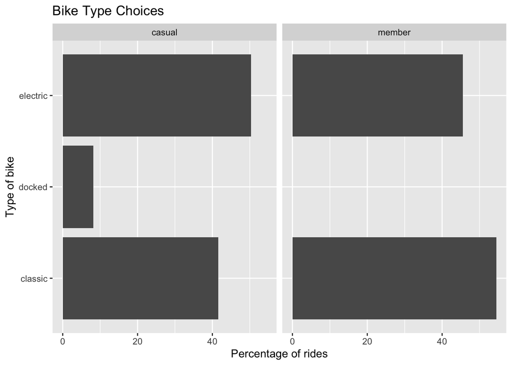

- No members use docked bikes
- Members use classic more than electric while casuals use electric more than classic

# How do members and casual differ in their ride durations?

| member_casual | median_duration_mins | total_duration_hours | mean_duration_mins | std_duration |
| --- | --- | --- | --- | --- |
| casual | 13.033 | 1135391.9 | 30.10545 | 283.31525 |
| member | 8.683 | 746042.4 | 12.51538 | 29.81876 |

| member_casual | median_distance_km | total_distance_km | mean_distance_km | std_distance_km |
| --- | --- | --- | --- | --- |
| casual | 1.657 | 4932813 | 2.185 | 9.484 |
| member | 1.505 | 7482507 | 2.093 | 12.856 |

- Casual and members travel similar distances.

# How do members and casual riders vary by days and months?

## By number of rides

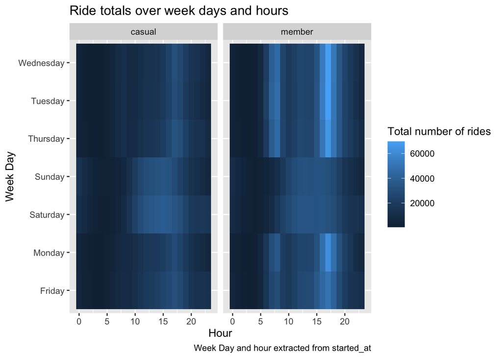

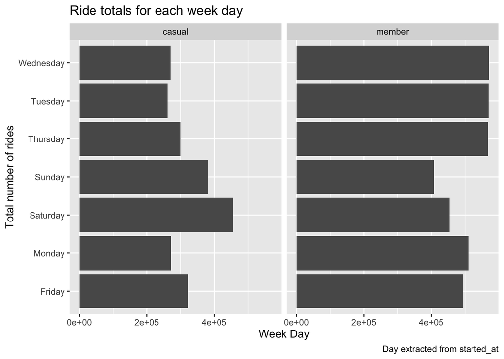

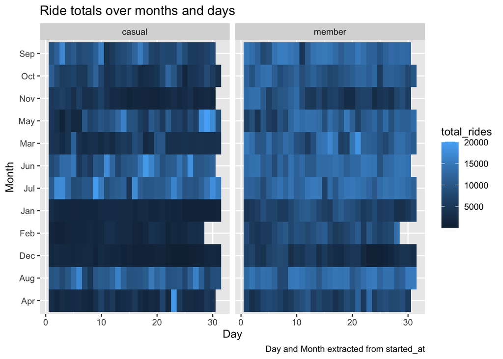

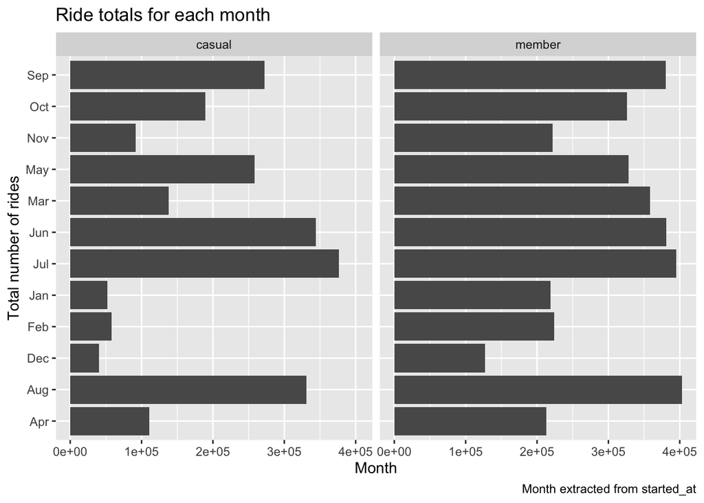

- Greatest number of rides occur during June to September for both members and casuals; July being the highest for casuals, August (with July close behind) for members.
- For both members and casuals, fewest number of rides happen during December
- Members ride in march considerably more than casuals do

## By duration of rides

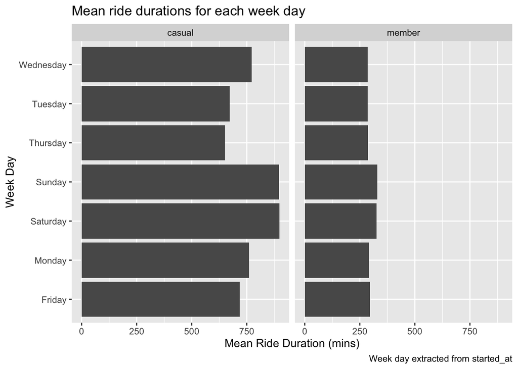

- Saturday and Sunday have the highest average ride durations for both Members and Casual riders.

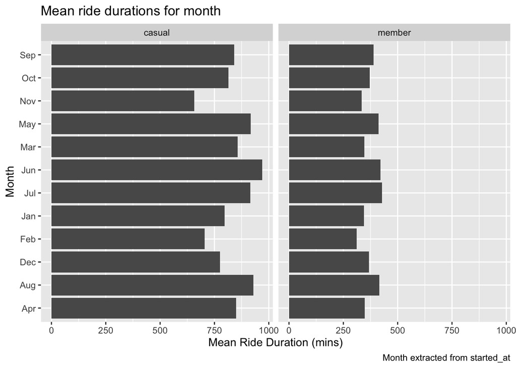

- Highest average ride durations occur for both casual and member riders from May to August
- November and February have the lowst average ride durations for both casual and member riders

## By distance of rides

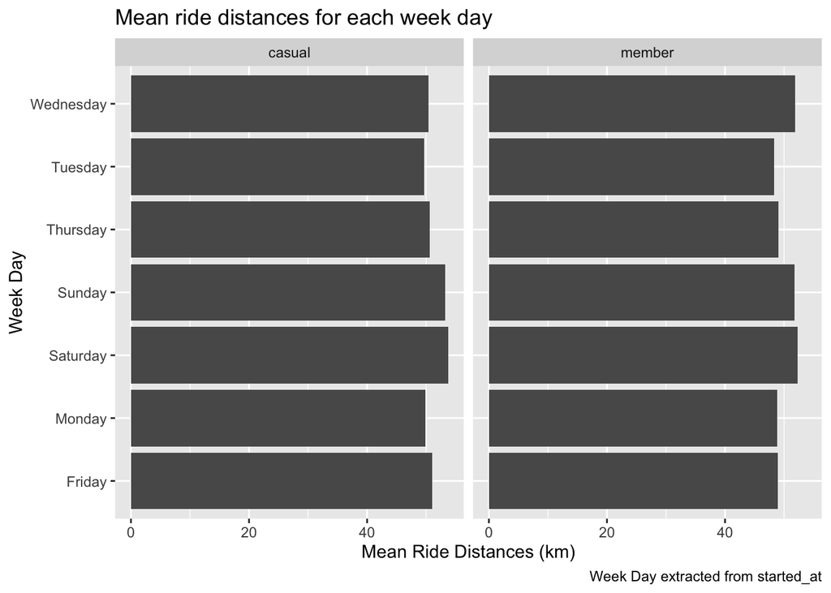

- Highest average distances occur for both member and casuals on Saturday and Sundays

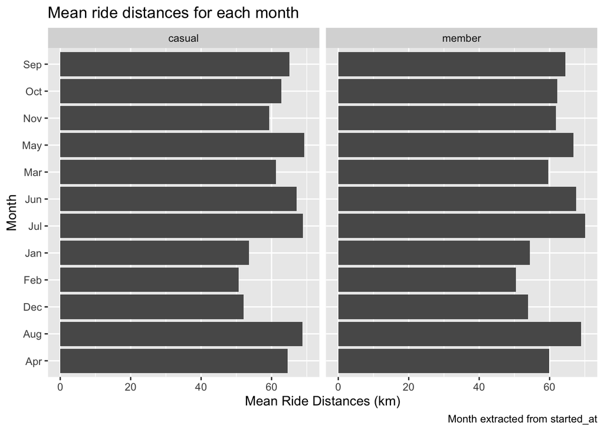

- Highest average ride durations occur for both casual and member riders from May to August

# How do members and casuals vary by location?

The stations congregate in the North Eastern region of Illinois, specically within and around the Chicago area.

Each location, start or end, were grouped by their given Chicago community using a Chicago shape file. A subset of this aggregated data by community is shown below.

| community | total_members | total_casuals | total_classic | total_docked | total_riders | total_starts | total_ends | mid_latitude | mid_longitude |
| --- | --- | --- | --- | --- | --- | --- | --- | --- | --- |
| ALBANY PARK | 14783 | 9749 | 7800 | 723 | 24532 | 5834 | 13 | 41.96539 | -87.71158 |
| ARCHER HEIGHTS | 1303 | 1495 | 0 | 0 | 2798 | 96 | 5 | 41.80362 | -87.72482 |
| ARMOUR SQUARE | 45444 | 25317 | 36965 | 3454 | 70761 | 11501 | 16 | 41.84575 | -87.63337 |
| ASHBURN | 242 | 142 | 0 | 0 | 384 | 5 | 15 | 41.74600 | -87.70411 |
| AUBURN GRESHAM | 1182 | 1426 | 824 | 61 | 2608 | 483 | 19 | 41.74284 | -87.65254 |
| AUSTIN | 5373 | 9052 | 3090 | 387 | 14425 | 2307 | 39 | 41.88648 | -87.76170 |

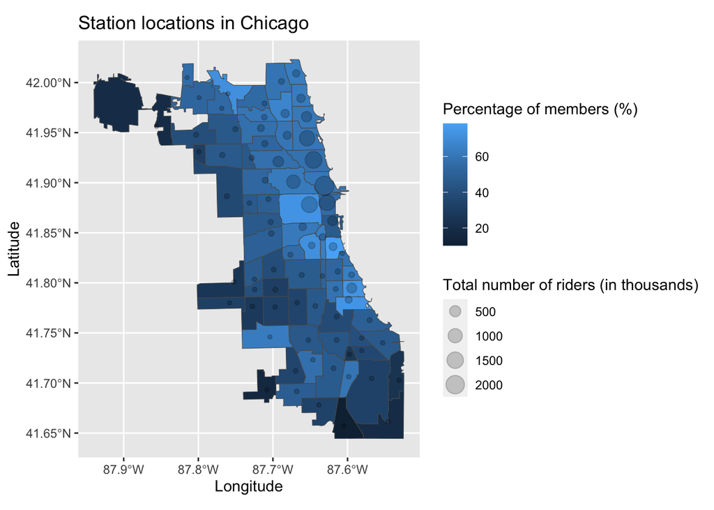

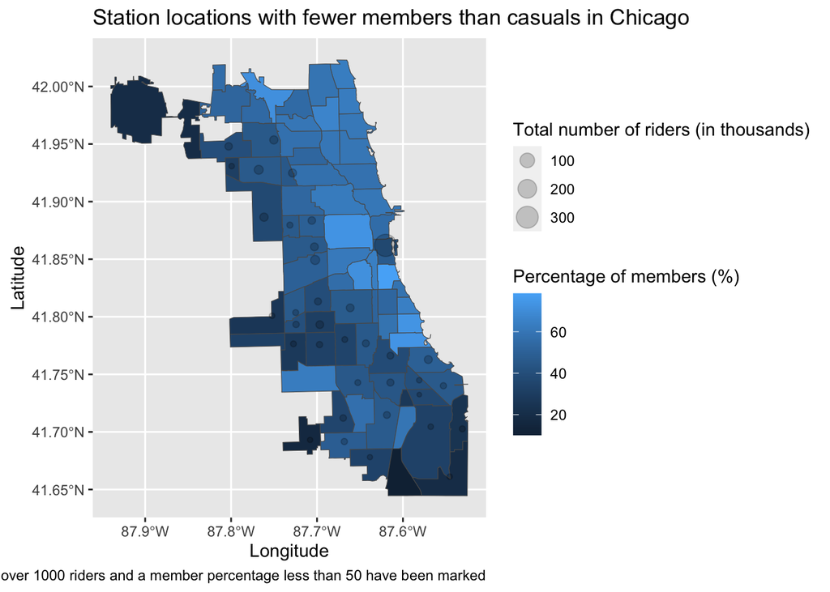

| community | member_percentage | total_riders | total_starts | total_ends |
| --- | --- | --- | --- | --- |
| NEAR SOUTH SIDE | 46.989 | 311608 | 54961 | 49 |
| SOUTH LAWNDALE | 49.787 | 20851 | 2876 | 33 |
| BELMONT CRAGIN | 46.179 | 20022 | 276 | 10 |
| AUSTIN | 37.248 | 14425 | 2307 | 39 |
| PORTAGE PARK | 45.599 | 13713 | 655 | 12 |
| HERMOSA | 45.462 | 12703 | 842 | 4 |
| SOUTH SHORE | 49.584 | 12024 | 1911 | 27 |
| NORTH LAWNDALE | 46.1 | 11232 | 1882 | 14 |
| NEW CITY | 47.133 | 11143 | 2169 | 30 |
| GAGE PARK | 31.194 | 10502 | 80 | 8 |

[output cut: 30 more lines]